# Bayesian Survival Analysis of Veteran Lung Cancer Patients: A Comparison of Weibull and Exponential Models

Emanuele Iaccarino

2025-06-19

### Data Understanding and Exploration

The Veteran dataset from the survival package in R contains data from a clinical trial conducted by the Veterans Administration to assess the efficacy of a new chemotherapy regimen for patients with advanced, inoperable lung cancer. The dataset includes 137 male patients, all of whom were randomly assigned to either a standard or test treatment group. The primary outcome is survival time (in days) from the start of treatment until death or censoring. A total of 128 patients died during the study, while 9 were right-censored, indicating a very high event rate (~93%).

[output not shown]

These variables are used to explain differences in survival across patient subgroups and to model hazard or survival time in a Bayesian framework. In particular, cell type and Karnofsky score are expected to have strong prognostic influence, while treatment assignment and prior therapy are evaluated for potential effect modification.

```r
str(veteran)
```

```
## 'data.frame':    137 obs. of  8 variables:
##  $ trt     : num  1 1 1 1 1 1 1 1 1 1 ...
##  $ celltype: Factor w/ 4 levels "squamous","smallcell",..: 1 1 1 1 1 1 1 1 1 1 ...
##  $ time    : num  72 411 228 126 118 10 82 110 314 100 ...
##  $ status  : num  1 1 1 1 1 1 1 1 1 0 ...
##  $ karno   : num  60 70 60 60 70 20 40 80 50 70 ...
##  $ diagtime: num  7 5 3 9 11 5 10 29 18 6 ...
##  $ age     : num  69 64 38 63 65 49 69 68 43 70 ...
##  $ prior   : num  0 10 0 10 10 0 10 0 0 0 ...
```

```r
# summary(veteran)
head(veteran)
```

```
##   trt celltype time status karno diagtime age prior
## 1   1 squamous   72      1    60        7  69     0
## 2   1 squamous  411      1    70        5  64    10
## 3   1 squamous  228      1    60        3  38     0
## 4   1 squamous  126      1    60        9  63    10
## 5   1 squamous  118      1    70       11  65    10
## 6   1 squamous   10      1    20        5  49     0
```

##### Distributions for numeric variables

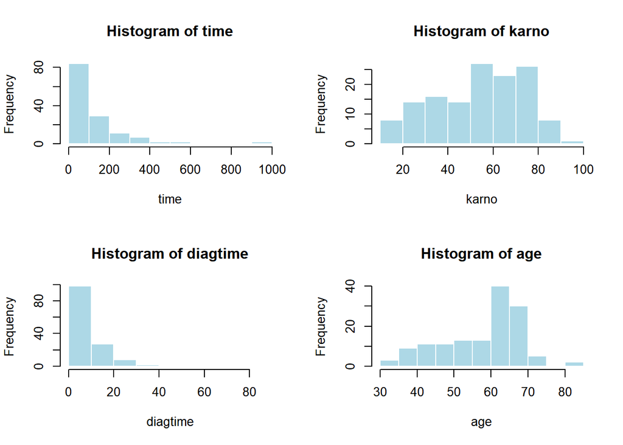

```
##       time           karno          diagtime           age
##  Min.   :  1.0   Min.   :10.00   Min.   : 1.000   Min.   :34.00
##  1st Qu.: 25.0   1st Qu.:40.00   1st Qu.: 3.000   1st Qu.:51.00
##  Median : 80.0   Median :60.00   Median : 5.000   Median :62.00
##  Mean   :121.6   Mean   :58.57   Mean   : 8.774   Mean   :58.31
##  3rd Qu.:144.0   3rd Qu.:75.00   3rd Qu.:11.000   3rd Qu.:66.00
##  Max.   :999.0   Max.   :99.00   Max.   :87.000   Max.   :81.00
```

**time** – Survival Time

is highly right-skewed (most patients died early; median ~80 days, max 999 days). This justifies using a skewed positive distribution like Weibull or Exponentia

**karno** – Karnofsky Score (Performance Status)

is roughly symmetric (mean ~58.5, median 60) but is expected to influence survival (higher score = better health)

**diagtime** – Time from Diagnosis to Randomization

is very skewed (most values 1–10, a few much larger)

**age**– Age in Years

Is 50–70 for most patients (slightly skewed), with an intuitive expectation that higher age worsens survival

##### Frequency Tables for Categorical Variables

```
##
## standard     test
##       69       68
```

```
##
##  squamous smallcell     adeno     large
##        35        48        27        27
```

```
##
##  no yes
##  97  40
```

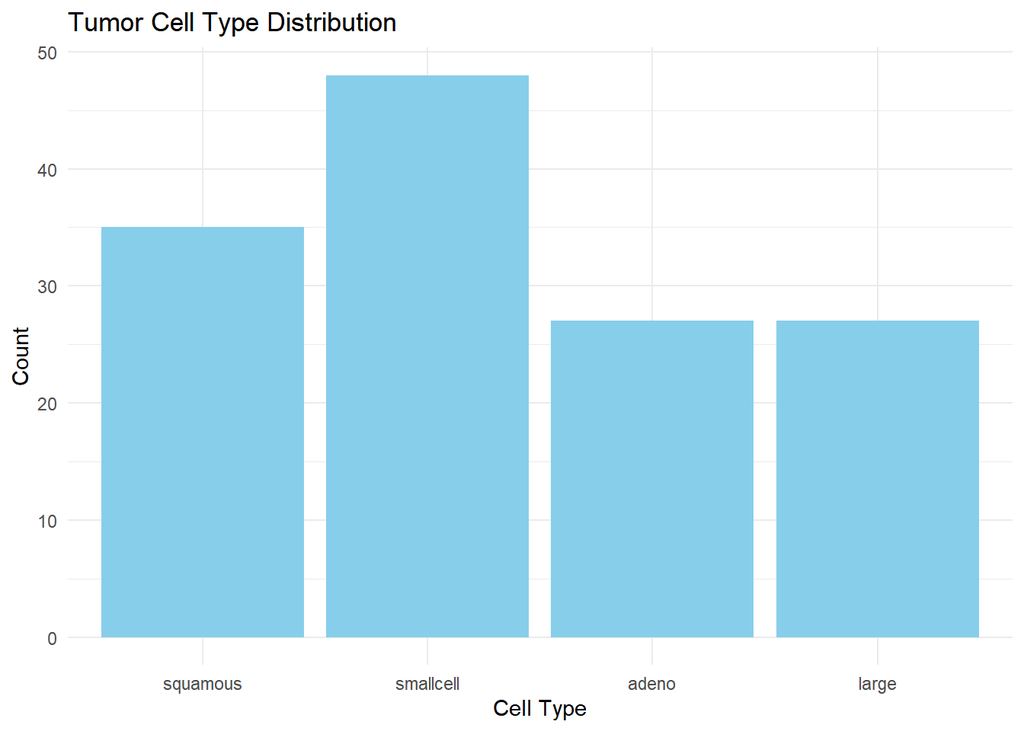

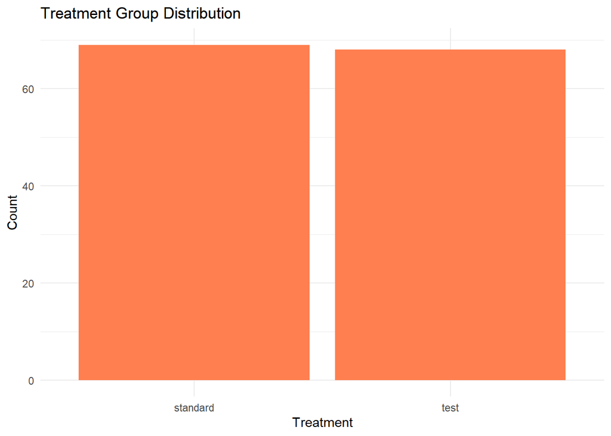

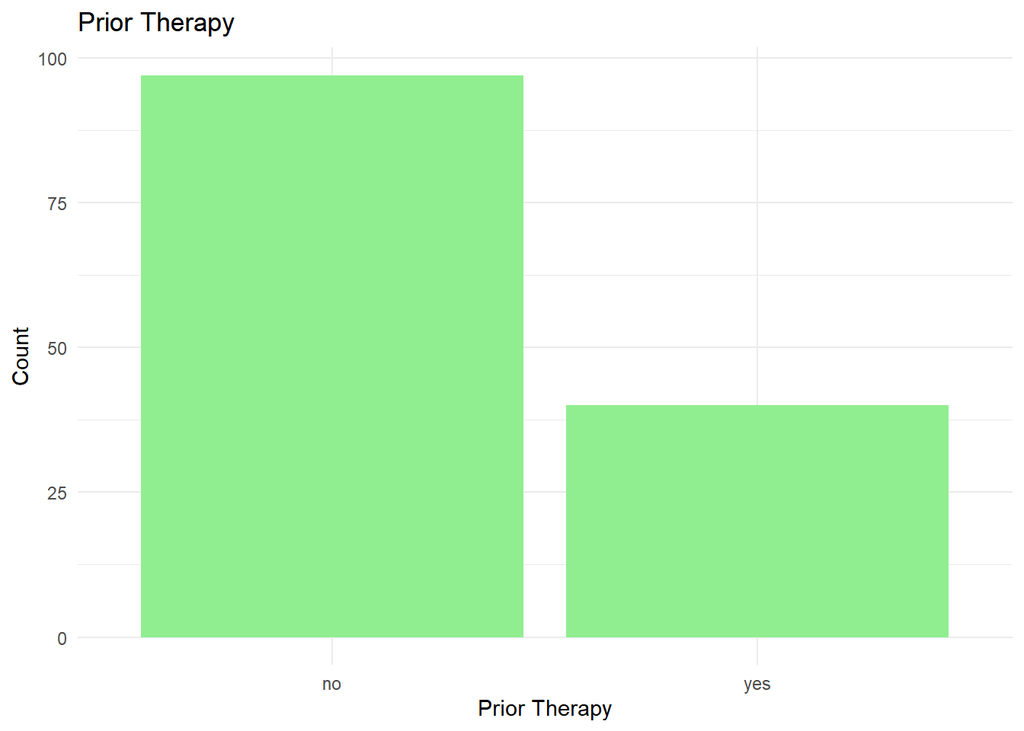

##### Event/Censoring Breakdown

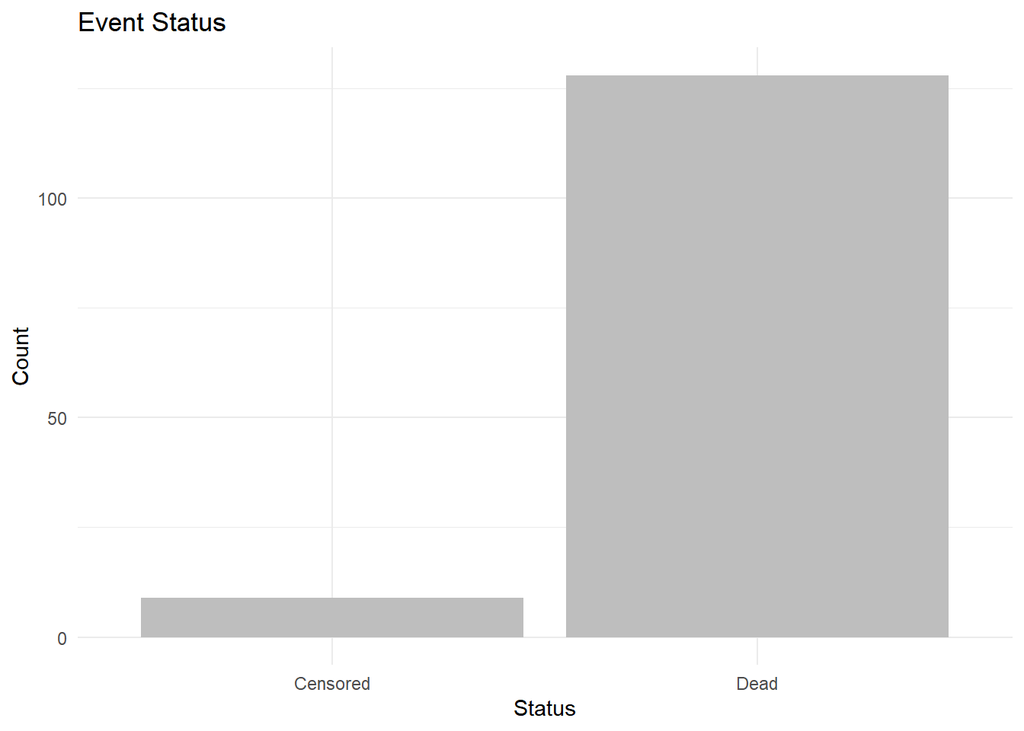

**status**– Event Indicator

- Deaths: 128 (**93.4%**)
- Censored: 9 (**6.6%**)

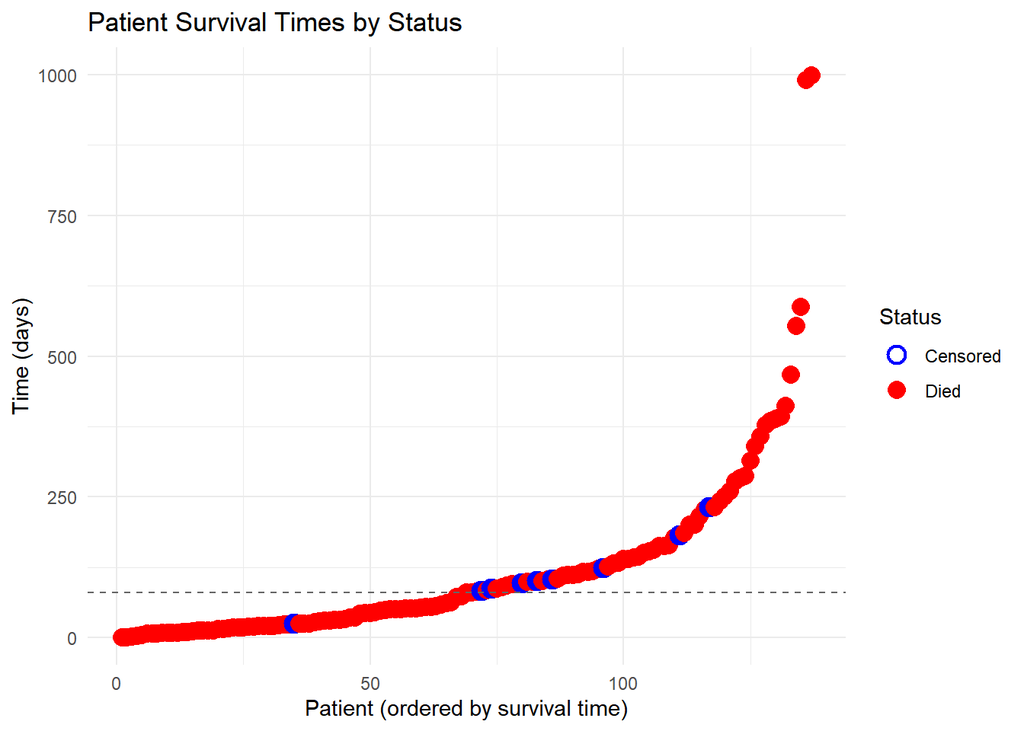

### From EDA to Survival Modeling: Key Takeaways

The exploratory analysis of the Veteran Lung Cancer dataset revealed patterns and complexities that rule out standard modeling techniques and point directly to the use of survival analysis.

The dataset captures the **time to death** of patients enrolled in a clinical trial for advanced lung cancer, along with clinical variables such as tumor cell type, treatment group, performance status (Karnofsky score), and others. Importantly, not all patients died during the study: a small number were **right-censored**, meaning they were still alive at last follow-up.

This outcome structure — **time-to-event data with censoring** — makes survival analysis not just appropriate, but necessary.

##### Why Linear or Classification Models Fall Short

One might consider predicting survival time using linear regression, or classifying patients as survived/died using logistic regression. However, both approaches are fundamentally inadequate in this context:

- **Linear regression** assumes continuous, normally distributed outcomes. But survival time is **positive**, **right-skewed**, and **censored**. These violations lead to biased or uninterpretable estimates.
- **Classification models** (like logistic regression) reduce survival to a binary outcome (event yes/no), **ignoring the timing** of the event and losing valuable information.

Most importantly, neither method can properly incorporate **censoring**, which is not missing data but a known bound on survival time.

### The Value of Survival Analysis

Survival analysis provides a principled way to:

- Model **time until an event** (e.g., death)
- Account for **censored observations**
- Estimate and compare **survival curves** across groups
- Evaluate how covariates affect the **hazard** or **surviv al time**

It allows us to move beyond the question *“Did the patient die?”* to more nuanced, time-aware questions like:

- *What is the probability a patient survives beyond 100 days?*
- *Which tumor types are associated with better survival outcomes?*
- *Does a higher Karnofsky score translate to longer survival?*

These are exactly the types of questions the Veteran dataset can help answer — provided we use the right tools.

### Kaplan–Meier Estimator (Nonparametrically Method)

Before choosing a specific survival model, it’s essential to understand the structure of the data without imposing parametric assumptions. The **Kaplan–Meier estimator** is ideal for this initial stage.

This nonparametric method estimates the survival function $S(t)$ — the probability a patient survives past time $t$ — directly from the data. It:

- Produces an intuitive **step function** that drops at observed event times
- **Naturally incorporates censoring** without requiring imputation
- Enables **visual and statistical comparisons** across subgroups (e.g., tumor cell type or treatment)

In this project, Kaplan–Meier curves revealed stark differences in survival across tumor cell types (e.g., squamous vs. small cell), while showing no notable effect of treatment — key insights that guided the selection of covariates in later modeling stages.

> By first exploring survival behavior empirically with Kaplan–Meier estimators, we can make more informed choices about which parametric models to fit — and which variables are likely to carry signal.

### Analysis by Treatment Group

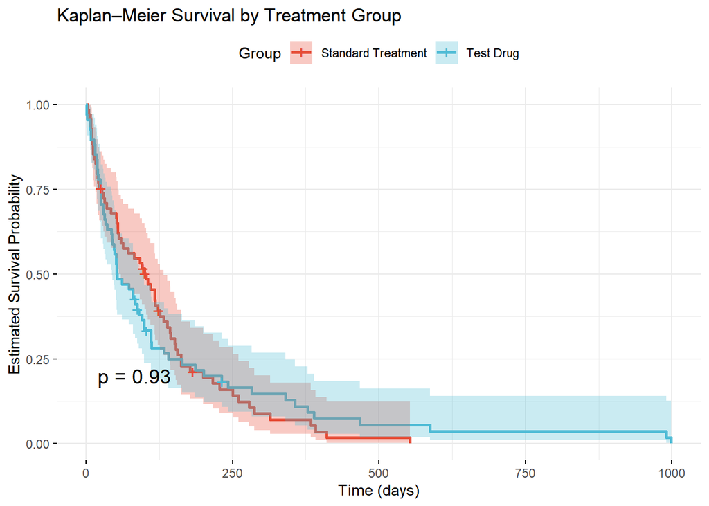

```r
surv_obj = Surv(time = veteran$time, event = veteran$status) # Survival object that we gonna use in every fit

# Fit KM by treatment
fit_trt = survfit(surv_obj ~ trt, data = veteran)

# Plot KM with:
ggsurvplot(
  fit_trt,
  data = veteran,
  censor = TRUE,
  pval = TRUE, # adds log-rank p-value automatically
  conf.int = TRUE, # Confidence Bands
  palette = c("#E64B35", "#4DBBD5"),
  legend.labs = c("Standard Treatment", "Test Drug"),
  legend.title = "Group",
  title = "Kaplan–Meier Survival by Treatment Group",
  xlab = "Time (days)",
  ylab = "Estimated Survival Probability",
  ggtheme = theme_minimal()
)
```

**Read the plot:**

- The **Y-axis** shows $\hat{S}(t)$, the estimated probability of surviving past time $t$
- Each **drop** occurs at an event (e.g., death)
- **Flat sections** indicate no events occurred
- **Censoring** is shown with a small **vertical tick** on the curve

**Interpretate the plot**

The Kaplan–Meier plot above compares the survival experiences of patients in the **Standard Treatment** group (red) and the **Test Drug** group (blue).

- **Both groups experience rapid early decline in survival probability** — more than half of patients in each group die within the first ~150 days.
- The **curves are very close together** throughout the entire time horizon, with substantial overlap in their confidence bands (shaded regions).
- By 500 days, the estimated survival probability in both groups is near 0, with only a few patients at risk.

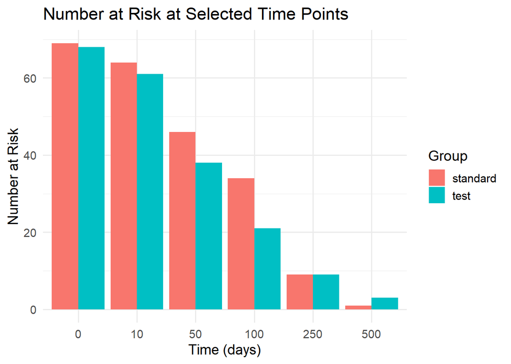

##### Log-Rank Test

The **log-rank test** is used to compare survival curves across multiple groups:

```r
lr_treat = survdiff(surv_obj ~ trt, data = veteran)

# Degrees of freedom = number of groups - 1
# in our case 2-1 = 1
p_val_treat = 1 - pchisq(lr_treat$chisq, df = 1)
p_val_treat
```

```
## [1] 0.9277272
```

> There is **no statistically significant difference** in survival between the Standard and Test treatment groups.

A p-value this high suggests the **null hypothesis** (that the survival functions are the same) cannot be rejected at any conventional significance level.

##### Descriptive statistic of findings

It was useful to get the same information we plotted more clearly above

```
##              records n.max n.start events    rmean se(rmean) median 0.95LCL
## trt=standard      69    69      69     64 123.9282  14.84352  103.0      59
## trt=test          68    68      68     64 142.0613  26.81071   52.5      44
##              0.95UCL
## trt=standard     132
## trt=test          95
```

- Patients in the **standard treatment group** survived a median of **103 days**, while those in the **test drug group** had a median of **52.5 days**. However, the **95% confidence intervals overlap**, indicating that the observed difference may not be statistically meaningful.
- The **restricted mean survival time (RMST)** is the average survival time up to the last observed time (truncated mean). Interestingly, the **test group has a higher RMST**, despite having a lower median. This suggests that while most patients in the test group died early, **a few survived much longer**, pulling the mean up. This reflects **skewness** in survival distributions — another reason to consider parametric models.

Again, confidence intervals overlap heavily, reinforcing the conclusion from the log-rank test:

> ❗ There is **no strong evidence** of a survival difference between treatment groups.

The **cumulative hazard function** $H(t)$ tells us: > The total accumulated risk of experiencing the event (e.g., death) **up to time $t$**.

It is related to the survival function by:
$$H(t) = -\log(S(t))$$

So while Kaplan–Meier plots show **survival probability**, the cumulative hazard plot shows **risk accumulation**.

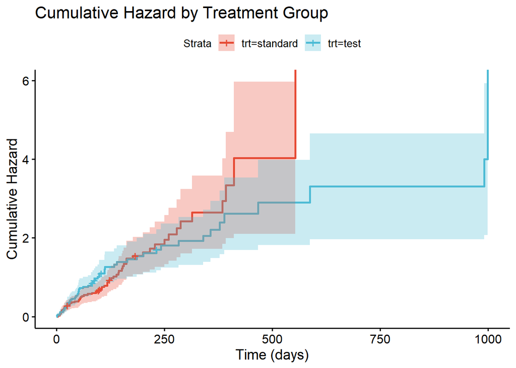

This plot **confirms** what we saw in the KM curves:

> No consistent or systematic difference in hazard between groups

Up to ~300 days, both groups accumulate hazard **at a similar rate**. After that point:

- The Standard group (red) appears to accumulate hazard more rapidly — a steep jump occurs late (~day 550).
- The Test group (blue) flattens out slightly, suggesting **lower late-stage risk**.

> these are likely outliers (as shown by wide CI previously) and here also both curves are largely **overlapping with wide confidence bands**, especially in the tails.

**Clinical and Modeling Implications**:

- The relatively **parallel shape** of the curves suggests **proportional hazards might be plausible**, but the lack of divergence means **modeling treatment effect may not improve predictive performance**.
- Any observed differences are likely due to **random variation** rather than true treatment effects.
- Therefore, when we build Bayesian models, **treatment group may not be a necessary covariate**.

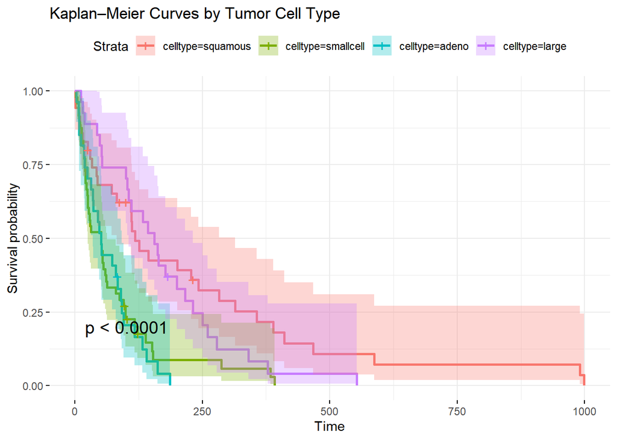

```r
fit_km_cell = survfit(Surv(time, status) ~ celltype -1 , data = veteran)
# levels(veteran$celltype)
# "squamous"  "smallcell" "adeno"     "large"
ggsurvplot(
  fit_km_cell,
  data = veteran,
  pval = TRUE,
  conf.int = TRUE,
  title = "Kaplan–Meier Curves by Tumor Cell Type",
  ggtheme = theme_minimal()
)
```

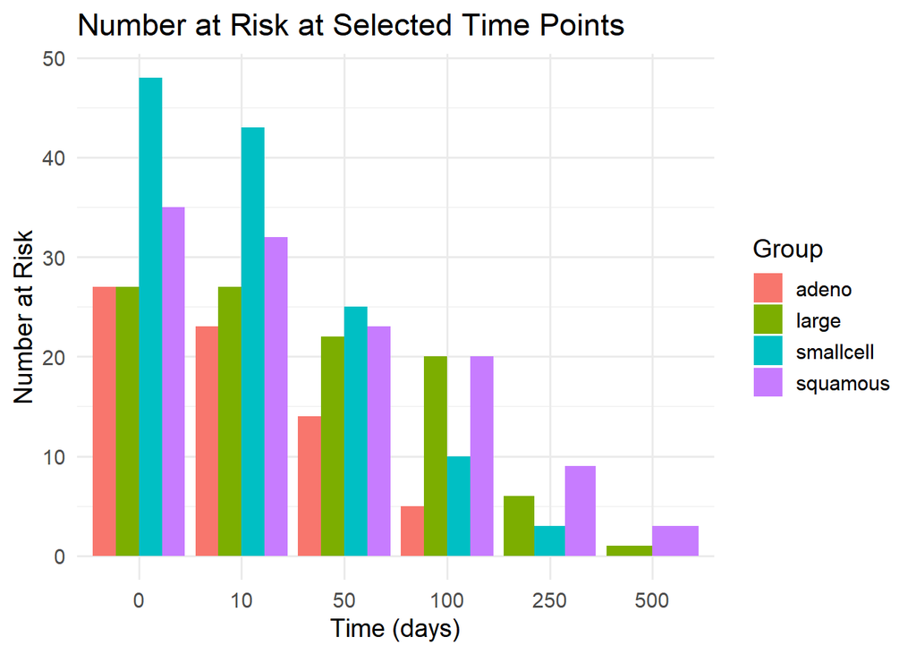

##### Log-Rank Test

```
## [1] 1.271246e-05
```

- The **log-rank test** comparing these curves yields a **p-value < 0.0001**, indicating:

  > There is **strong evidence** that survival differs across tumor cell types.

This result confirms that **celltype is a significant predictor of survival** and should be included in downstream survival models.

```
##                    records n.max n.start events     rmean se(rmean) median
## celltype=squamous       35    35      35     31 230.22506 47.686358    118
## celltype=smallcell      48    48      48     45  78.98110 14.671561     51
## celltype=adeno          27    27      27     26  65.55556  9.930286     51
## celltype=large          27    27      27     26 170.50617 24.610564    156
##                    0.95LCL 0.95UCL
## celltype=squamous       82     314
## celltype=smallcell      25      63
## celltype=adeno          35      92
## celltype=large         105     231
```

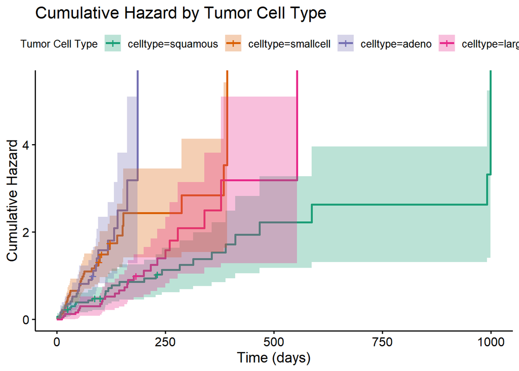

**Clinical and Modeling Implications**:

Our findings shows that:

- The **tumor cell type is strongly associated with differential mortality risk**.
- The **shapes of the cumulative hazard curves differ**, suggesting that the **hazard is not constant over time**.

  > This invalidates the exponential model assumption and supports using a **Weibull model**, which can capture increasing or decreasing hazards.

The clear separation and different slopes imply that **both the scale and shape of the hazard function vary by group** — ideal for a **parametric model with covariate effects**.

### Analysis by Prior Therapy

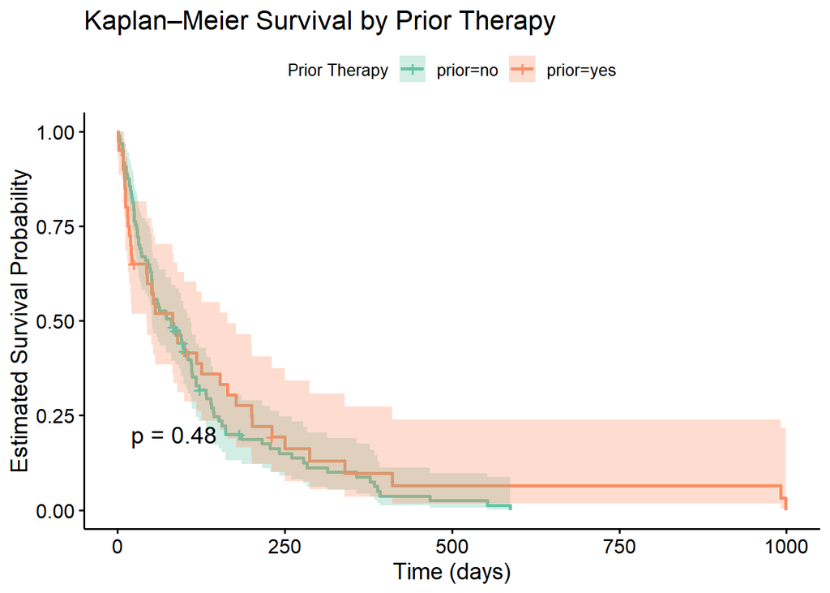

- Both groups show **similar early mortality patterns**.
- Survival probabilities decrease quickly in both groups within the first 200 days.
- The **curves overlap heavily**, and the confidence bands (shaded areas) intersect across nearly the entire time span.

##### Log-Rank Test

```
## [1] 0.4788932
```

> ❗ There is **no statistically significant difference** in survival between the two groups.

[output not shown]

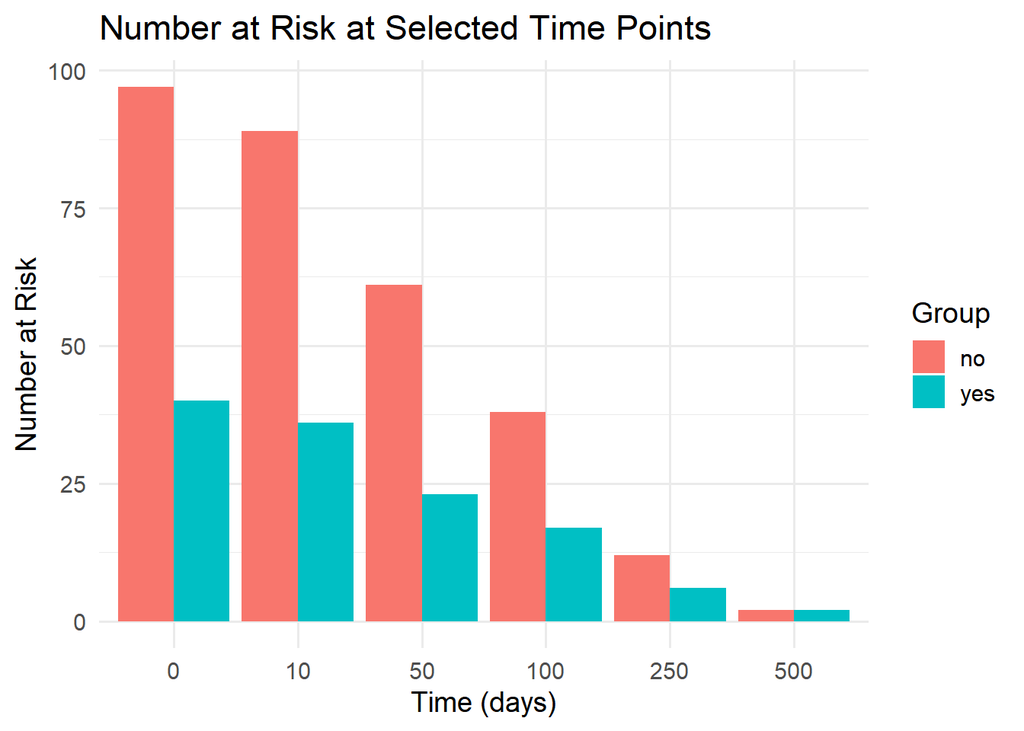

- Initially, there were more patients in the **“no prior therapy”** group than in the **“yes”** group, reflecting the original data imbalance.
- The decline in numbers over time is **parallel**, indicating **similar follow-up loss and event dynamics** in both groups.

This supports the conclusion that the lack of survival difference is not due to uneven dropout or censoring.

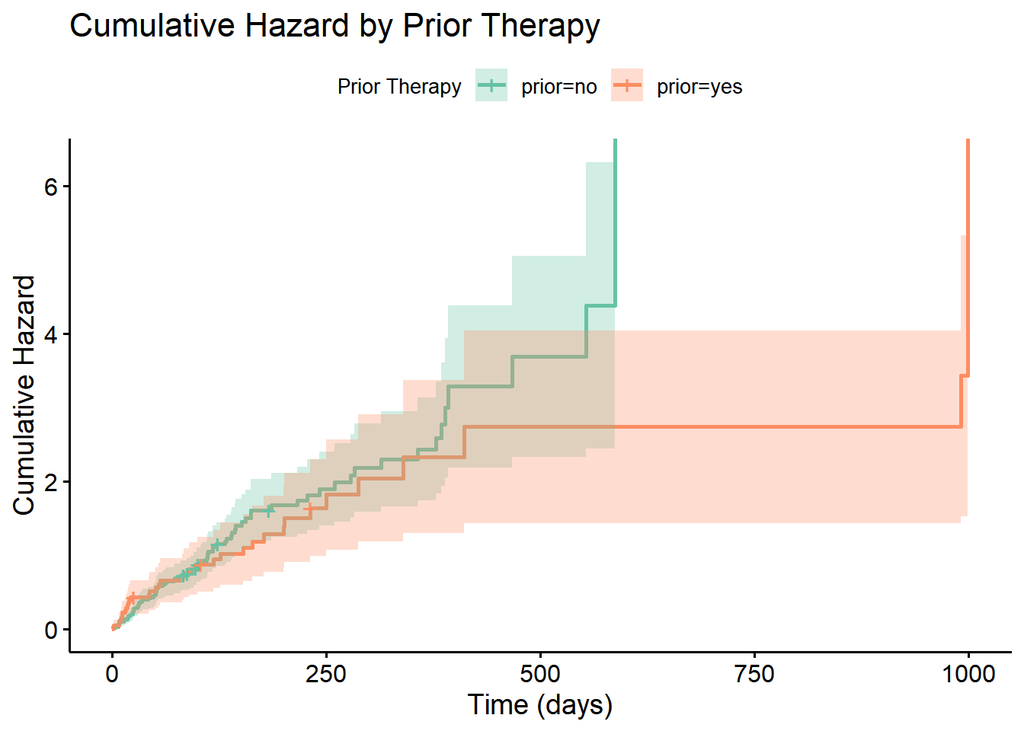

- The **curves for both groups track closely**, with no major separation.
- Slight late divergence appears (e.g., around 500–1000 days), but the wide confidence intervals make this **statistically insignificant**.

This confirms that **risk patterns are similar** regardless of prior treatment.

**Clinical and Modeling Implications**:

There is **no clinical or statistical evidence** to justify including `prior` as a main effect in the Bayesian parametric survival model.

## Exponential Survival Model

##### Theoretical Background

The **Exponential model** is the simplest parametric survival model. It assumes that the time-to-event $T$ follows an exponential distribution:

$$T \sim \text{Exponential}(\lambda)$$

where $\lambda > 0$ is the **rate parameter**. Alternatively, it can be expressed using the **scale** parameter $\theta = 1/\lambda$.

**Key Properties**

- **Survival Function**:
  $$S(t) = \exp(-\lambda t)$$
- **Hazard Function** (constant hazard):
  $$h(t) = \lambda$$
  The hazard does **not depend on time**, which means the model assumes a **constant risk of failure** over time.
- **Density Function**:
  $$f(t) = \lambda \exp(-\lambda t)$$
- **Cumulative Hazard Function**:
  $$H(t) = \lambda t$$
- **Mean and Median Survival Time**:
  $$\text{Mean} = \frac{1}{\lambda}, \quad \text{Median} =
  \frac{\log(2)}{\lambda}$$

The **Exponential model** is the most basic parametric survival model and serves as a natural starting point in survival analysis. It assumes that the time until an event (e.g., death) follows an **Exponential distribution**:

$$T \sim \text{Exponential}(\lambda),$$

where $\lambda > 0$ is the **rate parameter**. This model is memoryless, meaning the probability of the event occurring in the next instant is independent of how long the subject has already survived.

Alternatively, the model can be parameterized using the **scale parameter** $\theta = 1 / \lambda$.

**Key Characteristics**:

- **Survival Function**
  Describes the probability of surviving beyond time $t$:
  $$S(t) = \exp(-\lambda t)$$
- **Hazard Function**
  Gives the instantaneous risk of experiencing the event at time $t$:
  $$h(t) = \lambda$$
  This implies a **constant hazard over time**, which is a strong assumption — the risk of death does not increase or decrease with time.
- **Density Function**
  $$f(t) = \lambda \exp(-\lambda t)$$
- **Cumulative Hazard Function**
  $$H(t) = \lambda t$$
- **Moments**
  $$\text{Mean} = \frac{1}{\lambda}, \quad \text{Median} =
  \frac{\log(2)}{\lambda}$$

**When to Use the Exponential Model**:

The Exponential model is attractive for its simplicity and closed-form expressions, but it relies on a strong assumption: that the hazard function is **time-invariant**. This may be reasonable in settings where risk remains constant (e.g., electronic component failure), but is often unrealistic in medical applications like cancer survival, where risk typically **changes over time**.

So **Whats is his Role in This Analysis?**

Despite its limitations, the Exponential model serves as a useful **baseline** in this study:

- It provides a clear reference point for evaluating whether more flexible models (e.g., Weibull) improve fit.
- It allows for straightforward estimation of **covariate effects** on survival time or hazard, particularly under the **Accelerated Failure Time (AFT)** framework.
- Deviations from its assumptions (e.g., evidence of decreasing hazard) help justify model refinement.

In our case, early visualizations and posterior estimates suggest that the hazard rate **decreases over time**, violating the constant-hazard assumption — a key motivation for adopting the **Weibull model** later in the analysis.

##### Exponential Baseline Model (No Covariates)

```r
# Prepare data
exp_baseline_data = list(
  time = veteran$time,
  N = nrow(veteran)
)
```

```r
# Write JAGS model
cat("
model {
  for (i in 1:N) {
    time[i] ~ dexp(lambda)
  }

  lambda ~ dgamma(0.001, 0.001)
}
", file = "exponential_intercept.jags")
```

```r
# Run model
model = jags.model("exponential_intercept.jags", data = exp_baseline_data, n.chains = 3)
update(model, 1000)
exp_baseline_samples = coda.samples(model, variable.names = "lambda", n.iter = 5000)

# Summary
summary(exp_baseline_samples)
```

```
##
## Iterations = 1001:6000
## Thinning interval = 1
## Number of chains = 3
## Sample size per chain = 5000
##
## 1. Empirical mean and standard deviation for each variable,
##    plus standard error of the mean:
##
##           Mean             SD       Naive SE Time-series SE
##      8.228e-03      7.082e-04      5.782e-06      5.703e-06
##
## 2. Quantiles for each variable:
##
##     2.5%      25%      50%      75%    97.5%
## 0.006907 0.007736 0.008208 0.008694 0.009692
```

```
##      2.5%       50%     97.5%
##  71.51955  84.44874 100.34883
```

This close alignment with the KM estimate suggests that the exponential model gives a reasonable central tendency, even under its strict constant-hazard assumption.

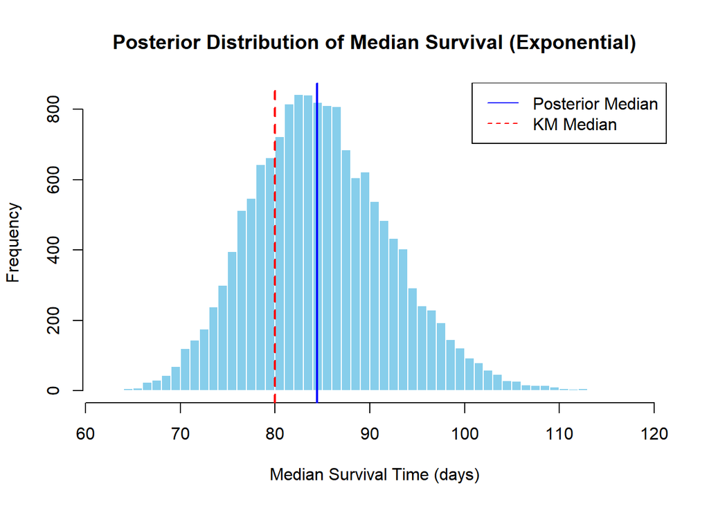

Model captures observed central survival tendency

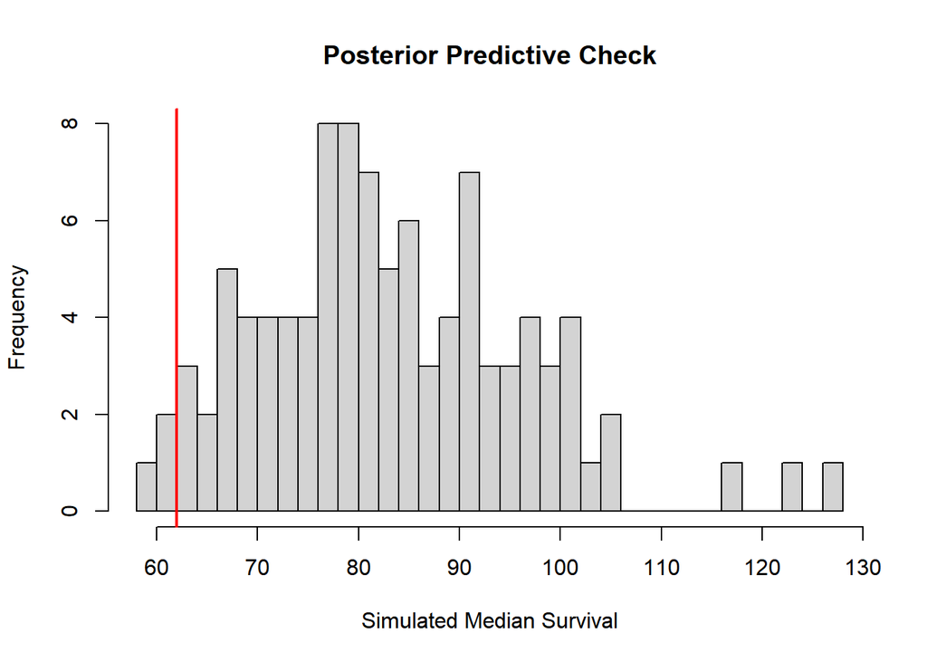

No evidence of gross misfit in predictive ability

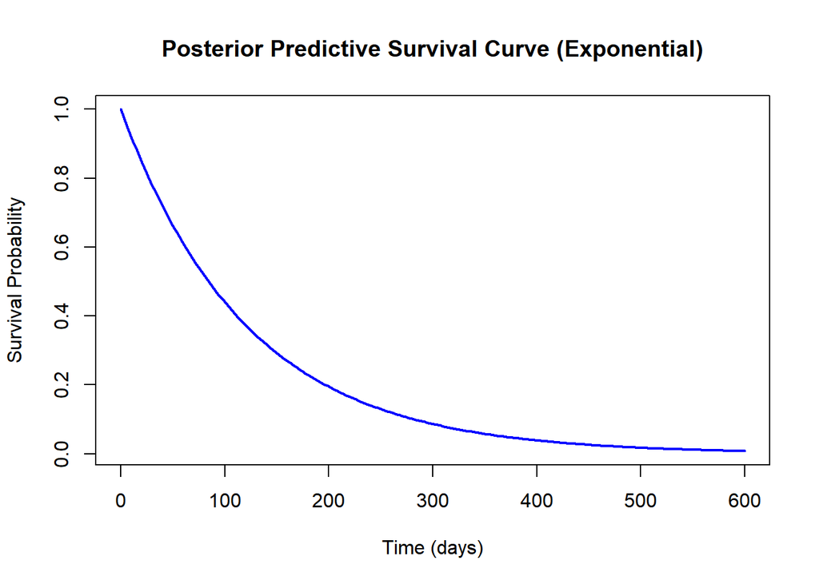

survival data exhibits early rapid decline followed by flattening (as seen previously), this constant decay may be too restrictive. Real data might require more flexible hazard.

### Convergence Diagnostics

In Bayesian analysis using MCMC, convergence diagnostics assess whether the Markov chains have stabilized and are sampling from the true posterior distribution. These checks are crucial to ensure that posterior summaries (like means, medians, or credible intervals) are reliable.

##### 1. Trace Plots

Trace plots display the sampled values of each parameter across iterations. A well-converged chain will exhibit a “hairy caterpillar” appearance—fluctuating around a constant mean with no apparent trends.

- **Good convergence**: horizontal bands, quick mixing.
- **Poor convergence**: trends, slow drift, or chains stuck in separate modes.

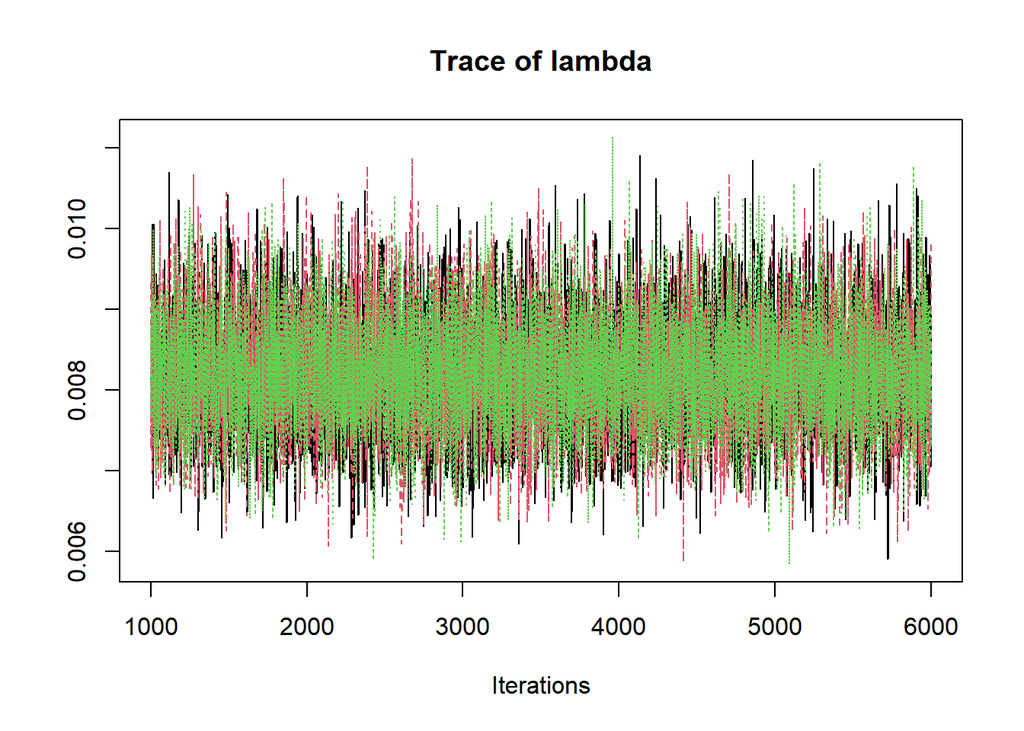

```r
traceplot(exp_baseline_samples)
```

The plot shows three chains (black, red, green), all fluctuating around a stable mean with no visible trends. This suggests good mixing and convergence.

##### 2. Gelman–Rubin Diagnostic ($\hat{R}$ or PSRF)

This diagnostic compares the variance **between chains** to the variance **within chains** for each parameter.

- $\hat{R} \approx 1$: chains have likely converged.
- $\hat{R} > 1.1$: potential non-convergence or insufficient mixing.
- Multiple chains are required for this diagnostic to be meaningful.

```r
gelman.diag(exp_baseline_samples)
```

```
## Potential scale reduction factors:
##
##        Point est. Upper C.I.
## lambda          1          1
```

**Perfect convergence.**

Meaning between-chain and within-chain variances agree, so chains have stabilized

##### 3. Autocorrelation

MCMC samples can be correlated, especially if chains move slowly through the posterior. Autocorrelation diagnostics measure how much one sample depends on previous samples.

- **High autocorrelation**: poor mixing and fewer effective samples.
- **Low autocorrelation**: more efficient sampling and better precision.

**N.B:**

autocorr.plot() plot autocorrelation for all $\beta$ coefficients, across 3 MCMC chains, so each coefficient is plotted once per chain

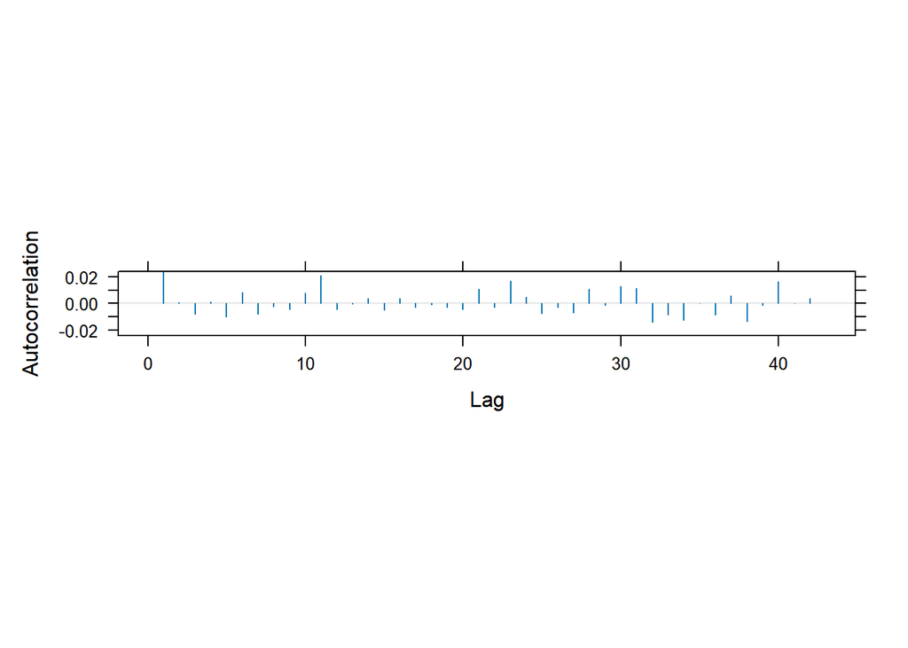

```r
# autocorr.plot(exp_baseline_samples)
combined <- as.mcmc(do.call(rbind, exp_baseline_samples))
acfplot(combined)
```

##### 4. Effective Sample Size (ESS)

Because of autocorrelation, the number of effectively independent draws is often much smaller than the number of total MCMC iterations. ESS estimates how many uncorrelated samples the chain provides.

- **High ESS (e.g. > 1000)**: reliable estimates.
- **Low ESS (e.g. < 200)**: may require more iterations or improved sampling.

```r
effectiveSize(exp_baseline_samples)
```

```
##   lambda
## 15459.42
```

it means that the 3 chains over 5000 iterations each (minus burn-in) produced many effectively independent samples

> To summarize: chain mixes well despite some autocorrelation

### (DIC) Deviance Information Criterion

The **Deviance Information Criterion (DIC)** is a Bayesian model comparison tool that balances model fit and complexity. It is conceptually similar to AIC in the frequentist setting but adapted for use with posterior distributions from MCMC.

DIC is defined as:

$$\text{DIC} = \overline{D(\theta)} + p_D$$

where:

- $D(\theta) = -2 \log p(y \mid \theta)$ is the **deviance**
- $\overline{D(\theta)}$ is the **posterior mean deviance**
- $p_D = \overline{D(\theta)} - D(\overline{\theta})$ is the **effective number of parameters**

An equivalent expression:

$$\text{DIC} = 2 \overline{D(\theta)} - D(\overline{\theta})$$

**Interpretation**

- Lower DIC indicates better expected predictive performance
- A DIC difference of:
  - **< 5** → weak evidence
  - **5–10** → moderate evidence
  - **> 10** → strong preference for the model with lower DIC

```r
dic_exp = dic.samples(model, n.iter = 5000)
dic_exp
```

```
## Mean deviance:  1590
## penalty 0.9921
## Penalized deviance: 1591
```

##### Manual DIC

the automatic DIC calculation, when we will add Covariated later, will **fails** with the following error:

```r
#Warning: Failed to set mean monitor for pD
#Support of observed nodes is not fixed
#Mean deviance: 0
#Penalty: 0
#Penalized deviance: 0
```

This failure happens because **JAGS cannot internally compute the deviance for models with censoring using `dinterval()`** — the likelihood is no longer a standard density like `dexp()` alone, but a **mixture of densities and survival functions**, and JAGS does not know how to compute deviance contributions from that.

To overcome this, we manually compute the **Deviance Information Criterion (DIC)** using the standard formula:

$$\text{DIC} = 2 \cdot \overline{D(\theta)} - D(\bar{\theta})$$

Where: - $\overline{D(\theta)} = -2 \cdot \text{mean log-likelihood over MCMC samples}$ - $D(\bar{\theta}) = -2 \cdot \text{log-likelihood evaluated at posterior mean}$

For survival data with censoring: - If $t_i$ is **uncensored**, the likelihood is:

$$f(t_i \mid \lambda_i) = \lambda_i e^{-\lambda_i t_i}
\quad \Rightarrow \quad \log f(t_i) = \log(\lambda_i) - \lambda_i t_i$$

- If $t_i$ is **right-censored**, the likelihood becomes the **survival function**:

$$S(t_i \mid \lambda_i) = P(T > t_i) = e^{-\lambda_i t_i}
\quad \Rightarrow \quad \log S(t_i) = -\lambda_i t_i$$

```r
posterior_mat = as.matrix(exp_baseline_samples)
lambda_samples = posterior_mat[, "lambda"]

# Log-verosimiglianza for each draw (sample)
loglik_vector = sapply(lambda_samples, function(lam) {
  ll = ifelse(
    veteran$status == 1,
    dexp(veteran$time, rate = lam, log = TRUE),
    log1p(-pexp(veteran$time, rate = lam))  # censored
  )
  sum(ll)
})

# DIC Calculations

D_bar = -2 * mean(loglik_vector)

lambda_hat = mean(lambda_samples)
loglik_hat = ifelse(
  veteran$status == 1,
  dexp(veteran$time, rate = lambda_hat, log = TRUE),
  log1p(-pexp(veteran$time, rate = lambda_hat))
)
D_hat = -2 * sum(loglik_hat)

DIC_exp_baseline = 2 * D_bar - D_hat
cat("Manual DIC (Baseline Exponential):", DIC_exp_baseline, "\n")
```

```
## Manual DIC (Baseline Exponential): 1504.959
```

### Exponential with Covariates(Tumor cell types)

**Modeling with Covariates: AFT Form**

In the **Accelerated Failure Time (AFT)** form, we model the log of survival time linearly:

$$\log(T_i) = \mu_i + \epsilon_i, \quad \epsilon_i \sim \text{Gumbel}(0,
1/\lambda)$$

or equivalently,

$$T_i \sim \text{Exponential}(\lambda_i), \quad \lambda_i = \exp(-X_i^\top
\beta)$$

```r
# design matrix for tumor cell type
# (no intercept to estimate baseline directly)
#  so each tumor type gets its own coefficient.

X_celltype = model.matrix(~ celltype, data = veteran)
#levels(veteran$celltype)
#colnames(model.matrix(~ celltype, data = veteran))

t = ifelse(veteran$status == 1, veteran$time, NA)
c = veteran$time
c[veteran$status == 1] = 99999  # so JAGS sees a defined value

censor = 1 * (veteran$status == 1)

exp_AFT_celltypes_data = list(
  N = nrow(veteran),
  t = t,
  c = c,
  censor = censor,
  X = X_celltype,
  K = ncol(X_celltype)
)
```

```r
cat("
model {
  for (i in 1:N) {
    censor[i] ~ dinterval(t[i], c[i])
    t[i] ~ dexp(lambda[i])
    log(lambda[i]) = -inprod(beta[], X[i,]) # # AFT-style linear predictor
  }

  for (j in 1:K) {
    beta[j] ~ dnorm(0, 0.01)
  }
}
", file = "exponential_aft.jags")
```

```r
model = jags.model("exponential_aft.jags", data = exp_AFT_celltypes_data, n.chains = 3, n.adapt = 1000)
update(model, 1000)
exp_AFT_celltypes_samples = coda.samples(model, c("beta"), n.iter = 5000)
summary(exp_AFT_celltypes_samples)
```

```
##
## Iterations = 2001:7000
## Thinning interval = 1
## Number of chains = 3
## Sample size per chain = 5000
##
## 1. Empirical mean and standard deviation for each variable,
##    plus standard error of the mean:
##
##            Mean     SD Naive SE Time-series SE
## beta[1]  5.2696 0.1709 0.001395       0.004654
## beta[2] -1.0471 0.2255 0.001842       0.005671
## beta[3] -1.1208 0.2604 0.002126       0.005797
## beta[4] -0.1619 0.2592 0.002117       0.005672
##
## 2. Quantiles for each variable:
##
##            2.5%     25%     50%      75%   97.5%
## beta[1]  4.9477  5.1501  5.2631  5.38170  5.6118
## beta[2] -1.4924 -1.1985 -1.0465 -0.89154 -0.6095
## beta[3] -1.6270 -1.2925 -1.1216 -0.94680 -0.6094
## beta[4] -0.6581 -0.3378 -0.1606  0.01262  0.3513
```

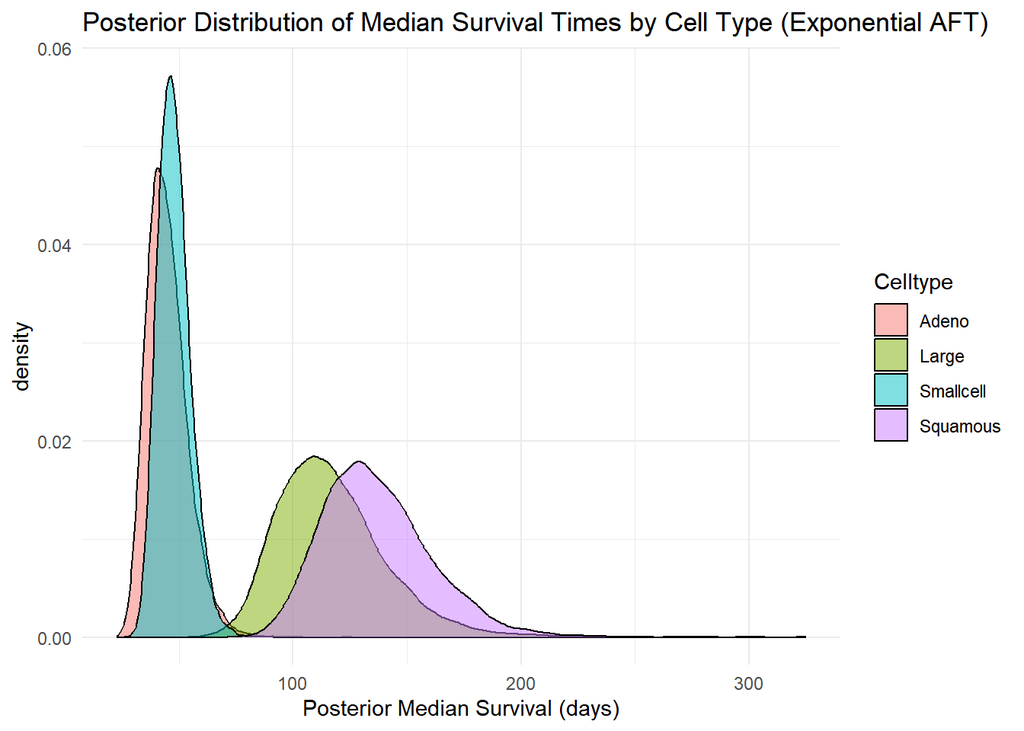

- Squamous (purple): Exhibits the longest predicted survival, with a wider right-skewed distribution. This suggests that patients with squamous cell carcinoma tend to survive longer, though there is moderate variability.
- Large cell (green): Has the second-longest survival, with slightly tighter uncertainty. This group appears to have relatively good prognosis after squamous.
- Small cell (blue): Shows a shorter survival distribution, indicating that patients with small cell carcinoma have generally poorer outcomes.
- Adenocarcinoma (red): Displays the shortest median survival, with a narrow and sharply concentrated distribution. This suggests a consistently poor prognosis in this group, with little variation across posterior samples.

Overall, the Bayesian estimates align well with clinical expectations and the nonparametric Kaplan–Meier curves: squamous and large cell types show better survival outcomes, while small cell and especially adenocarcinoma are associated with worse prognosis.”

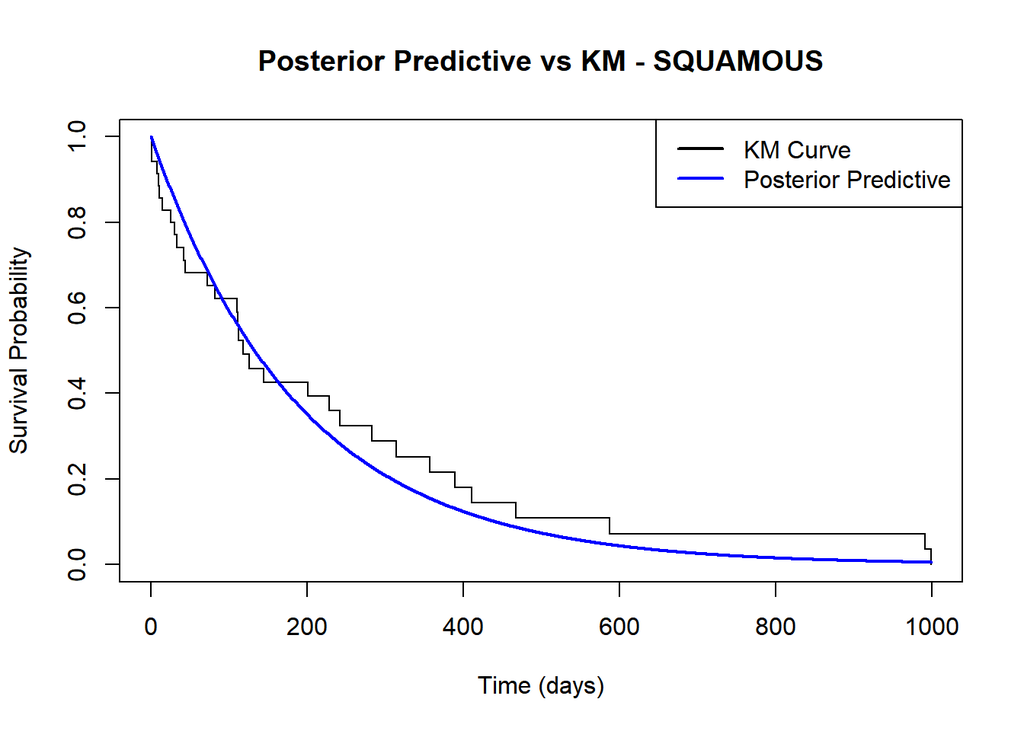

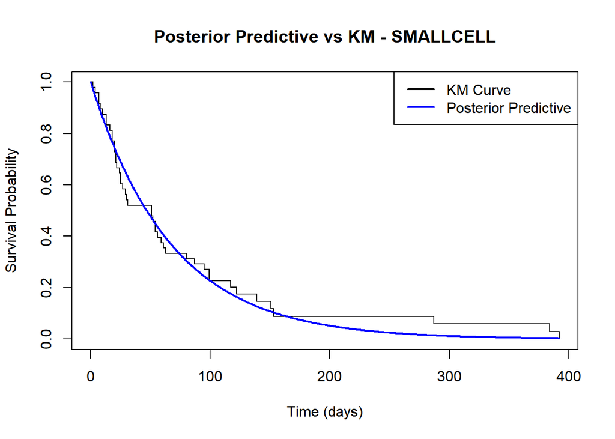

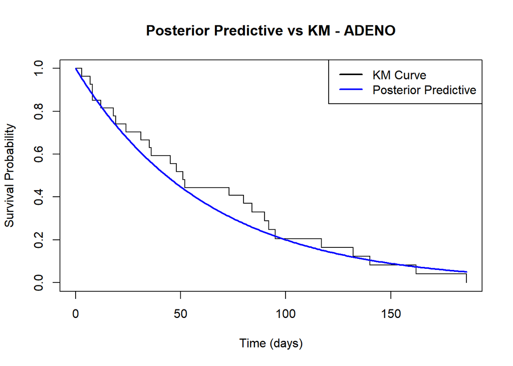

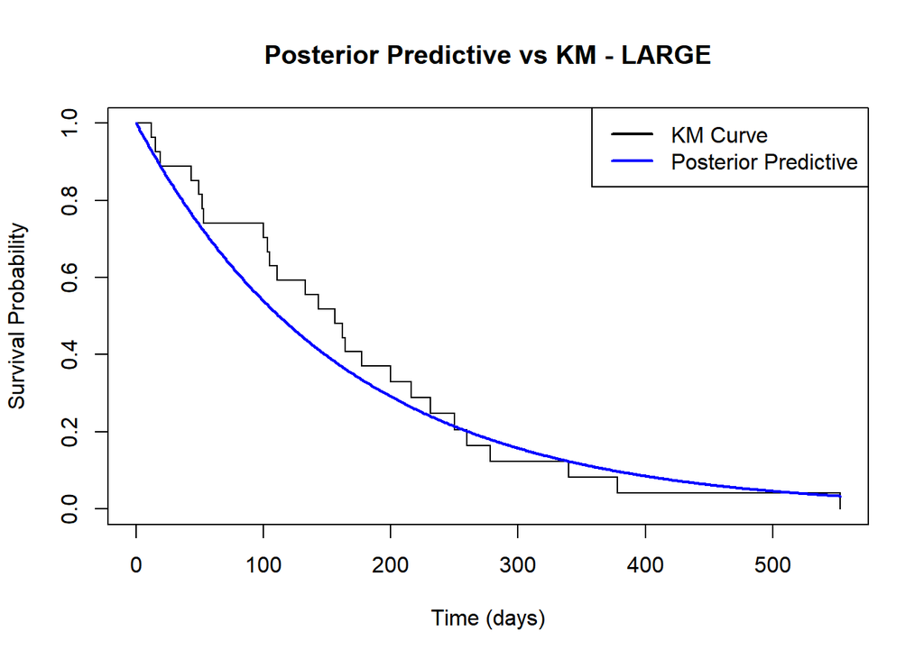

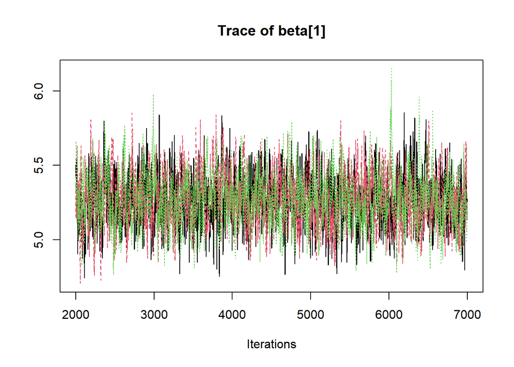

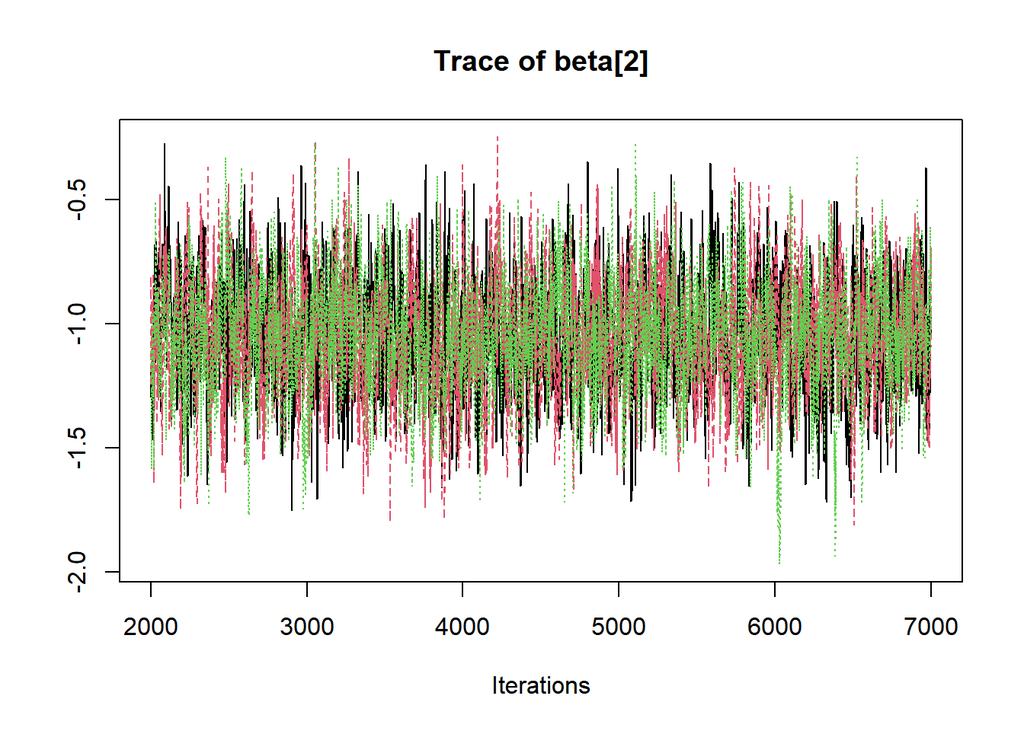

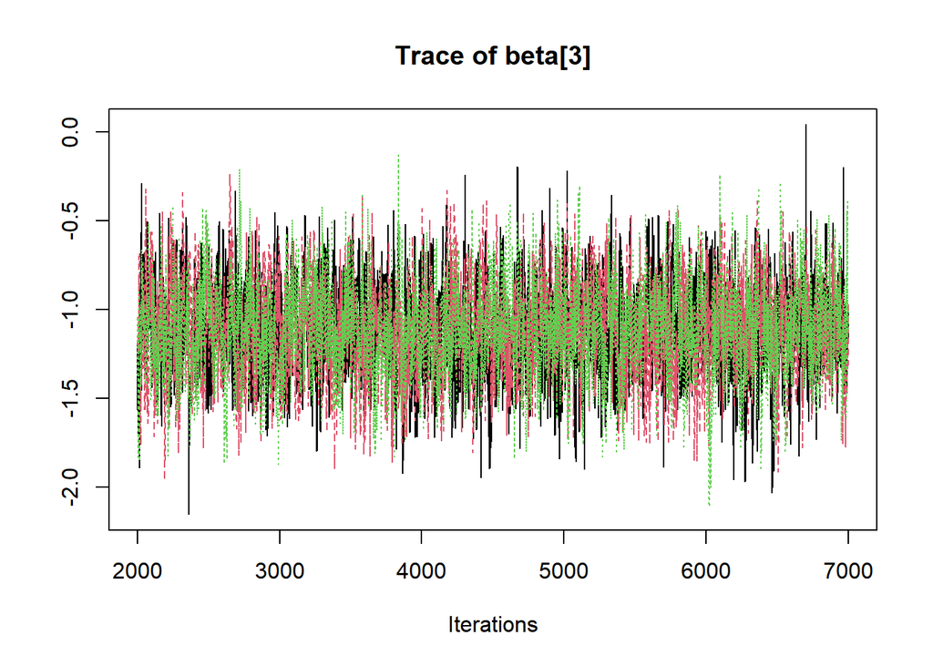

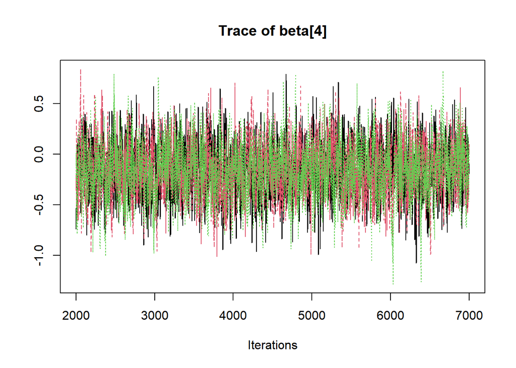

The trace plots for beta[1] to beta[4] show stable oscillation without drift, indicating that the MCMC chains are well-mixed and exploring the posterior space. There are no signs of non-convergence (e.g., trends or stickiness).

```
## Potential scale reduction factors:
##
##         Point est. Upper C.I.
## beta[1]          1          1
## beta[2]          1          1
## beta[3]          1          1
## beta[4]          1          1
##
## Multivariate psrf
##
## 1
```

All values 1, which strongly suggests that convergence has been reached across chains. This supports the visual impression from the trace plots.

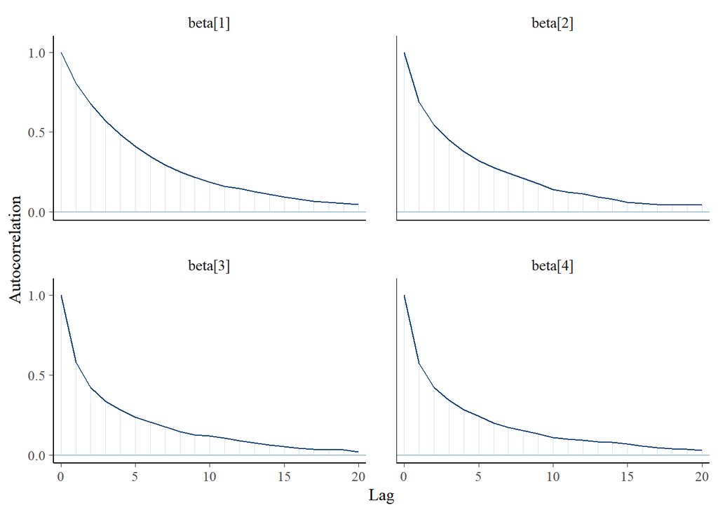

```
##  beta[1]  beta[2]  beta[3]  beta[4]
## 1350.407 1598.491 2042.860 2124.485
```

The value reported, according to the Rule of thumb: ESS > 1000 is generally considered very good for stable estimation.

```
## Manual DIC: 1478.373
```

### Exponential model with all covariates

```r
X = model.matrix(~ celltype + age + karno + diagtime + prior + trt , data = veteran)

time_obs = veteran$time
status   = veteran$status
censor_upper = ifelse(status == 1, 9999, time_obs)

# Build list for JAGS
exp_data_complete_AFT = list(
  N = nrow(veteran),
  K = ncol(X),
  X = X,
  t = time_obs,
  c = censor_upper,
  isCensored = 1 - status
)
```

```r
cat("
model {
  for (i in 1:N) {
    # Linear predictor with all covariates
    eta[i] = inprod(beta[], X[i, ])
    lambda[i] = exp(-eta[i])

    # Censoring model
    isCensored[i] ~ dinterval(t[i], c[i])
    t[i] ~ dexp(lambda[i])
  }

  # Priors for all regression coefficients
  for (j in 1:K) {
    beta[j] ~ dnorm(0, 0.01)
  }
}
", file = "exponential_aft_censored.jags")
```

```r
model = jags.model("exponential_aft_censored.jags", data = exp_data_complete_AFT,
                    n.chains = 3, n.adapt = 1000)
update(model, 1000)
exp_complete_AFT_samples = coda.samples(model, variable.names = c("beta"), n.iter = 5000)
summary(exp_complete_AFT_samples)
```

```
##
## Iterations = 2001:7000
## Thinning interval = 1
## Number of chains = 3
## Sample size per chain = 5000
##
## 1. Empirical mean and standard deviation for each variable,
##    plus standard error of the mean:
##
##              Mean       SD  Naive SE Time-series SE
## beta[1]  3.109891 0.686463 5.605e-03      0.0718095
## beta[2] -0.787644 0.246798 2.015e-03      0.0064976
## beta[3] -1.037576 0.264904 2.163e-03      0.0054027
## beta[4] -0.272783 0.261734 2.137e-03      0.0053913
## beta[5]  0.007484 0.008769 7.160e-05      0.0007079
## beta[6]  0.028522 0.005004 4.086e-05      0.0002654
## beta[7]  0.002479 0.009189 7.503e-05      0.0001688
## beta[8] -0.057348 0.216251 1.766e-03      0.0034492
## beta[9] -0.188739 0.191196 1.561e-03      0.0038097
##
## 2. Quantiles for each variable:
##
##              2.5%       25%       50%       75%    97.5%
## beta[1]  1.771824  2.639711  3.117716  3.570478  4.47114
## beta[2] -1.291858 -0.950479 -0.786420 -0.618964 -0.29855
## beta[3] -1.538901 -1.217841 -1.042081 -0.855670 -0.51595
## beta[4] -0.777915 -0.447686 -0.274441 -0.099468  0.25121
## beta[5] -0.009388  0.001429  0.007515  0.013413  0.02511
## beta[6]  0.018350  0.025199  0.028608  0.031917  0.03810
## beta[7] -0.014043 -0.003873  0.001881  0.008378  0.02213
## beta[8] -0.470227 -0.207165 -0.058961  0.088605  0.37101
## beta[9] -0.561502 -0.317941 -0.189080 -0.058873  0.18838
```

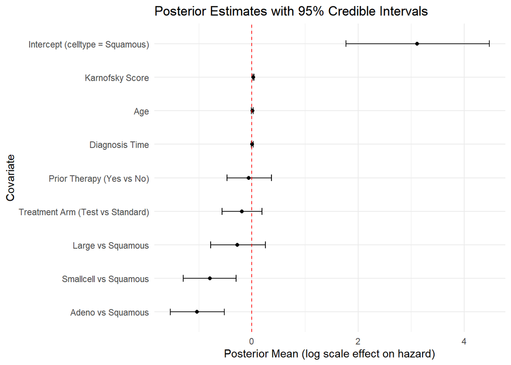

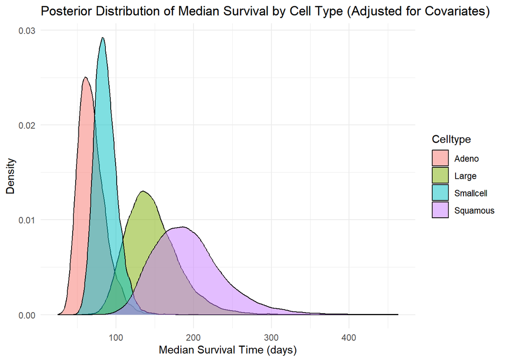

The model now reflects conditional effects, i.e., “given the same average age, health score, etc”, it other words we adjusted for those covariates known to influence survival.